MSc Neuroscience, GSN

# Multitask Dale’s-law RNNs under rate and synaptic budgets

Atharv Suryawanshi

## One circuit, many tasks

[figure not shown]

When one circuit does many tasks, do its neurons share the work, or split into task-specific groups?

## Yang et al. 2019: one network, 20 tasks

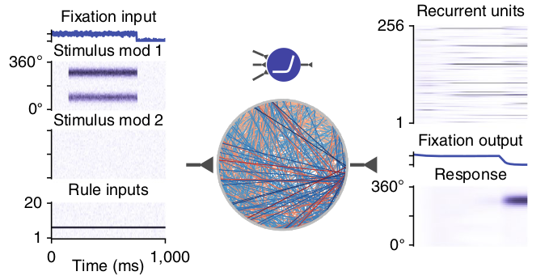

256 RNN units trained on 20 cognitive tasks at once: fixation, two stimulus rings and a rule input in; fixation and a response ring out.

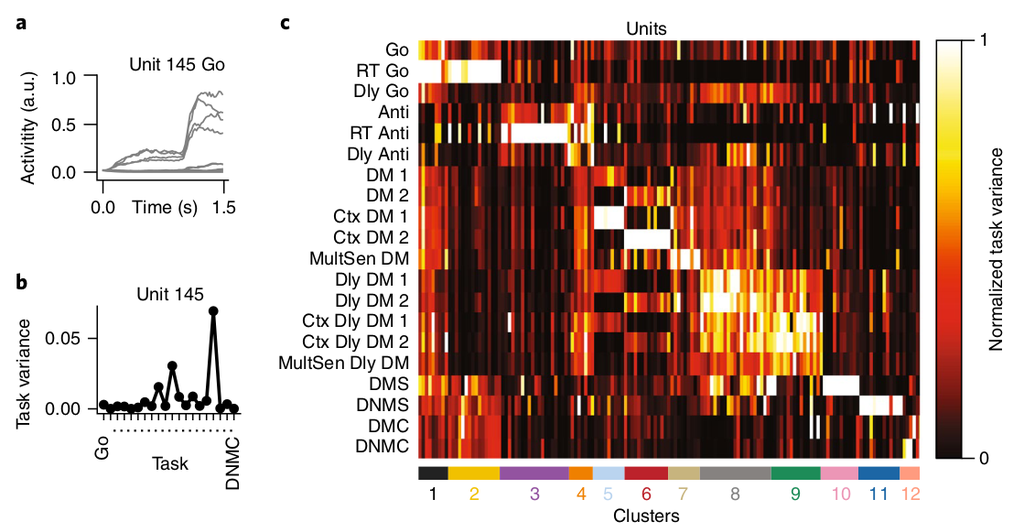

Task variance: how much each neuron takes part in each task. Neurons form clusters, each specialised for a group of related tasks.

Trained on many tasks, one network forms groups of neurons for related tasks.

Yang, Joglekar, Song, Newsome & Wang (2019). *Nat. Neurosci.* 22, 297–306. Figs 1b, 2a–c.

## Song, Yang & Wang 2016: excitatory and inhibitory neurons

[figure not shown]

$$\begin{aligned}
\tau\dot{\mathbf{x}} &= -\mathbf{x} + W^{\mathrm{rec}}\mathbf{r} + W^{\mathrm{in}}\mathbf{u} + \text{noise}\\
\mathbf{r} &= [\mathbf{x}]_+, \qquad \mathbf{z} = W^{\mathrm{out}}\,\mathbf{r}_{\color{#1F8AD0}{\mathrm{E}}}\\[4pt]
W^{\mathrm{rec}} &= W^{\mathrm{rec},+}\,D, \qquad W^{\mathrm{rec},+} \geq 0\\
D &= \mathrm{diag}(\underbrace{\color{#1F8AD0}{+1,\dots,+1}}_{\text{E}},\ \underbrace{\color{#E0393E}{-1,\dots,-1}}_{\text{I}})
\end{aligned}$$

Dale’s law: each neuron is excitatory or inhibitory (80 / 20); the sign of its outgoing synapses is fixed.

One network per task (decision making, working memory, …); activity resembles recordings.

Separate E and I neurons (80/20): we keep this in all our networks.

Song, Yang & Wang (2016). *PLoS Comput. Biol.* 12(2), e1004792. Fig. 1, Eqs 1–3, 12.

## Real neurons pay for activity and for synapses

Activity costs energy: most of the brain’s energy goes into spikes and synaptic transmission.

Attwell & Laughlin 2001; Lennie 2003

Synapses cost space and material: axons and dendrites take up most of the grey matter.

Chklovskii, Schikorski & Stevens 2002

No single cost is minimised. The best solutions form a trade-off (Pareto) front, each weighting the objectives differently; there is no single optimum.

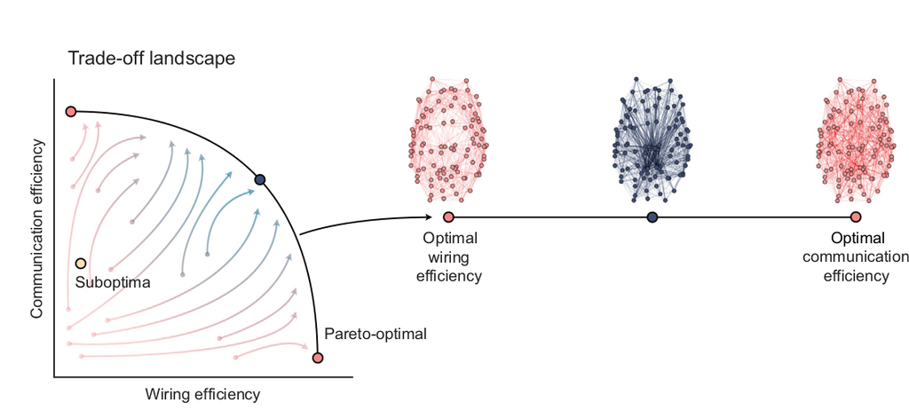

Brain networks trade wiring cost against communication efficiency: suboptimal networks lie inside, Pareto-optimal ones on the frontier.  
Fakhar & Astle (2026). *Trends Cogn. Sci.* Fig. 1.

What does a circuit look like when it must solve many tasks and pay both costs, and where on the trade-off does it sit?

## Setup

Each network is scored on three things: task accuracy, synaptic cost and rate cost.

## The network

$$\begin{aligned}
\mathbf{r}_t &= (1-\alpha)\,\mathbf{r}_{t-1} + \alpha\,\big[\,W^{\mathrm{in}}\mathbf{u}_t + W^{\mathrm{rec}}\mathbf{r}_{t-1} + \mathbf{b} + \sigma\boldsymbol{\xi}_t\,\big]_+,
\qquad \alpha = \Delta t/\tau = 20\,\text{ms}/100\,\text{ms}\\[8pt]
W^{\mathrm{rec}} &= \big(\mathrm{softplus}(\Theta)\odot(\mathbf{1}-I)\big)\,D,
\qquad D = \mathrm{diag}(\underbrace{\color{#1F8AD0}{+1,\dots,+1}}_{204\ \text{E}},\ \underbrace{\color{#E0393E}{-1,\dots,-1}}_{52\ \text{I}})\\[8pt]
\hat{\mathbf{y}}_t &= \mathrm{sigmoid}\big(W^{\mathrm{out}}\,\mathbf{r}^{\color{#1F8AD0}{\mathrm{E}}}_t + \mathbf{b}^{\mathrm{out}}\big)
\end{aligned}$$

$\mathrm{softplus}(\Theta) \geq 0$: synaptic strengths. $D$: fixed sign of each presynaptic neuron (Dale). $\mathbf{1}-I$: no autapses.

Output read from E neurons only. Input, recurrent and output synapses all learned (gradient descent, 150k steps).

A rate network with Dale’s law: each neuron is E or I, and only E neurons project to the output.

## Three objectives

Task
$$L_{\text{task}} = \Big\langle \frac{\sum_{t,k} m_{tk}\,(\hat y_{tk} - y_{tk})^2}{\sum_{t,k} m_{tk}} \Big\rangle_{\text{trials}}$$

Squared error where the target matters ($m$), each trial weighted equally.

Rate
$$C_{\text{rate}} = \big\langle\, r_i(t)^2 \,\big\rangle_{\text{trials},\,t,\,i}$$

Mean squared rate over trials, time and neurons.

Synaptic
$$C_{\text{syn}} = \frac{1}{N(N-1)} \sum_{i \neq j} \frac{|W^{\mathrm{rec}}_{ij}|}{c_j}$$
$$c_j = \begin{cases} 1 & j \in \color{#1F8AD0}{\text{E}}\\ n_{\text{E}}/n_{\text{I}} & j \in \color{#E0393E}{\text{I}} \end{cases}$$

Total recurrent synaptic strength. I synapses are about 4× stronger, so we divide by $c_j$; otherwise inhibition would be cut first.

Three objectives: do the tasks, keep rates low, keep total synaptic strength low.

## Synaptic budget: a hard limit

Synaptic cost: hard limit

After every learning step, the same amount $\theta$ is subtracted from every synapse until the total strength is back at the budget; synapses that reach zero are removed. This is subtractive normalisation (Miller & MacKay 1994), the rule that drives weak synapses to zero. Here there is one budget for the whole network, not one per neuron.

$$|W_{ij}| \leftarrow \max\big(|W_{ij}| - \theta,\ 0\big),\quad \theta:\ C_{\text{syn}} = B_{\text{syn}}$$

| $\|W_{ij}\|$ | strength of the synapse from neuron $j$ to neuron $i$ |
| --- | --- |
| $c_j$ | 1 if $j$ is E, $n_{\text{E}}/n_{\text{I}}$ if I (I synapses are about 4× stronger) |
| $C_{\text{syn}}$ | synaptic cost: mean of $\|W_{ij}\|/c_j$ over all synapses |
| $B_{\text{syn}}$ | synaptic budget: the ceiling on $C_{\text{syn}}$ |
| $\theta$ | amount taken from every synapse, set so that $C_{\text{syn}} = B_{\text{syn}}$ |

Hard limit: after every step the total synaptic strength is exactly at budget, and the weakest synapses go first.

Miller & MacKay 1994; Duchi et al. 2008 (L1 projection).

## Rate budget: a soft limit

Rate cost: soft limit

Rates can’t be cut like synapses, so the rate cost is added to the loss with a weight $\lambda$ that is learned: it rises while the network is above budget and falls while it is below, like integral control of firing-rate homeostasis towards a set point (Turrigiano 2008; O’Leary et al. 2014).

$$\begin{aligned}
L &= L_{\text{task}} + \lambda\,C_{\text{rate}} + \tfrac{\rho}{2}\,B_{\text{rate}}\big[\tfrac{C_{\text{rate}}}{B_{\text{rate}}} - 1\big]_+^2\\
\log\lambda &\leftarrow \log\lambda + \eta\,\big(\tfrac{C_{\text{rate}}}{B_{\text{rate}}} - 1\big)
\end{aligned}$$

The $\rho$ term pushes back at once, in proportion to the overshoot, and only above budget; $\lambda$ removes what is left. In training the rate cost settles on its budget.

| $L$ | loss, minimised by gradient descent |
| --- | --- |
| $L_{\text{task}}$ | task error |
| $C_{\text{rate}}$ | rate cost: mean squared firing rate |
| $B_{\text{rate}}$ | rate budget: the ceiling on $C_{\text{rate}}$ |
| $\lambda$ | weight of the rate cost, learned during training |
| $\rho$ | strength of the push-back ($\rho = 1$) |
| $[x]_+$ | $\max(x, 0)$: counts only above budget |
| $\eta$ | how fast $\lambda$ changes (0.01 per step) |

No hand-set trade-off: each network gets two ceilings $(B_{\text{rate}}, B_{\text{syn}})$ and does the tasks as well as it can under them.

Turrigiano 2008; O’Leary et al. 2014.

## Mapping the front: NSGA-III

initialise budgets

→

train

→

check: every task ≥ 0.6

→

rank: front

→

breed new budgets

↺

[interactive chart not shown]

Objectives: worst-task accuracy up, rate cost and synaptic cost down.

Each point is one network, trained under its own pair of budgets.

Front: networks where no objective can improve without another getting worse.

NSGA-III keeps the front and a spread along it, then makes new budgets from them.

One real search, generations 0 and 1 (48 networks each).

The search chooses the budgets, training does the rest; over generations the population moves onto the front.

Deb & Jain 2014 (NSGA-III); Blank & Deb 2020 (pymoo).

## The front

[interactive chart not shown]

drag to turn

Control

Rate constraint

Synaptic constraint

Both constraints

on the front (116)

other networks

×fails a task (floor)

worst-task accuracy

0.60.81.0

Surface: smoothed accuracy of all networks that do every task; the next slide shows it from above.

4 NSGA-III searches, 573 networks: 532 do every task ($\geq 0.6$), 116 on the front. Stars: the four points (next slide), mean of 5 seeds.

Accuracy is set mainly by the synaptic budget: a plateau, then a cliff once synaptic cost drops below about $10^{-2.5}$.

## Four points on the front

[figure not shown]

One line per network, 5 per point. Grey: its 20 tasks; coloured dot: its worst task, which sets worst-task accuracy. Vertical line and number: mean over the 5 networks; name: the most common worst task.

Three constrained points with similar accuracy (0.92–0.94) but a different cost limiting each: 200× lower rates, 2–3% of synapses kept, or both.

## Do they converge?

[figure not shown]

One seed per point, same budgets as the 5 seeds; evaluated at saved checkpoints (1k–125k steps) and at the end (150k). Dotted: 0.6, every task must reach it.

All four points do every task by 100k steps. The worst task is the slow one: with the rate constraint, DNMS stays at chance (0.5) until 75k.

## Like-to-like connectivity

Task variance
$$\mathrm{TV}_i(a) = \big\langle \mathrm{Var}_{\text{trials}}\, r_i(t) \big\rangle_t$$

Variance of neuron $i$’s rate across trials of task $a$, averaged over time (Yang et al. 2019).

Normalized task variance
$$x_{i,a} = \frac{\mathrm{TV}_i(a)}{\max_b \mathrm{TV}_i(b)} \in [0, 1]$$

Neuron $i$’s profile over the 20 tasks.

Similarity, synapses
$$r_{ij} = \mathrm{corr}(x_i, x_j)$$

Connected $j \to i$: $|W^{\mathrm{rec}}_{ij}| / c_j > 0.01$. Per type: E→E, E→I, I→E, I→I.

AUC
$$\mathrm{AUC} = P(r_{\text{conn}} > r_{\text{unconn}})$$

0.5: no relation; above: like-to-like. Doesn’t depend on how many synapses are kept.

Question: are neurons that work in the same tasks more likely to be connected? (Example: both constraints, seed 0.)

Yang et al. 2019; significance: profiles shuffled within E and within I, synapses fixed, 500×.

## Like-to-like connectivity: example network

[figure not shown]

One network per point (seed 0). Grey: unconnected pairs; line: connected pairs. Small square: ROC (false vs true positive rate); number: AUC, black if $p < 0.05$, grey “n.s.” if not.

With a synaptic budget, connected neurons have more similar task profiles than unconnected ones; under control and the rate budget the two distributions overlap.

## Like-to-like connectivity: all 20 networks

[figure not shown]

For each connection type: ROC, mean over 5 seeds (band: seed range), and AUC per network, filled if $p < 0.05$; grey lines join the same seed.

Synapses kept: control 70%, rate 61%, synaptic 2.7%, both 1.8%.

Cutting control and rate-constraint networks to 1.8% afterwards (strongest synapses kept) gives AUC $\leq 0.54$.

Like-to-like connectivity comes with the synaptic budget, and is strongest where the fewest synapses are left (both constraints, AUC 0.61–0.66). Pruning a dense network afterwards does not produce it.

## Normalized task variance analysis at the four points

[figure not shown]

One network per point (seed 0, the most typical of the 5). Columns: neurons sorted by group; strip: group membership (k-means on the profiles, k chosen by silhouette, next slide).

Under a rate budget E neurons take part in fewer tasks (3.1 vs 5.0 per neuron, every seed) and split into more groups. A synaptic budget alone leaves them as broad as control (4.7).

## Task variance and the number of groups

Reminder

Profile: normalized task variance $x_i$ over the 20 tasks (slide 15).

Groups: k-means on the profiles, E and I separately.

$$s = \frac{b - a}{\max(a, b)}$$

$a$: mean distance to its own group, $b$: to the nearest other group.

Chosen $k$: the highest peak with $k > 2$.

[figure not shown]

Under a rate budget the groups are the most distinct (highest silhouette, E and I) and the most numerous. The exact $k$ is soft: the curves are flat.

## Does a rate budget make neurons more selective?

[figure not shown]

20 networks: the 4 points, 5 seeds each.

Tasks per neuron: tasks where the neuron’s normalized task variance is above 0.5. Silhouette: the best over $k = 3$–$20$, per network. For E it peaks at $k$ = 11–19 with a rate budget, at $k = 3$ (the edge) in control.

E: lower rate cost, fewer tasks per neuron and more distinct groups (Spearman with rate cost over the 20 networks: tasks +0.90, silhouette −0.72).

I: weaker (tasks +0.52, silhouette −0.64).

A rate budget makes E neurons more task-selective: the lower the rate cost, the fewer tasks per neuron and the more distinct the groups. A claim about selectivity, not about a number of groups.

## Lesions: does a rate budget make functions separable?

Selectivity describes activity. The causal test: take neurons away and see which tasks fail (Yang et al. 2019; Driscoll et al. 2024).

Group for task $a$: the $m$ neurons with the largest task variance on $a$, E and I separately. Same $m$ in every network, no clustering.

Lesion (mean-clamp): $r_i(t) \to \bar r_i(t)$ for every $i$ in the group, the intact network’s trial-average for that task and time step. Removes the task information the neurons carry, keeps their mean drive (silencing, $r_i = 0$, also removes the drive).

Damage on task $b$: $d_{a,b} = \max(0,\ \mathrm{acc}_b - \mathrm{acc}_b^{\,\text{lesioned}})$, all 20 tasks.

$$\text{family specificity} = \frac{\big\langle d_{a,b} \big\rangle_{b \in F(a),\ b \neq a}}
{\big\langle d_{a,b} \big\rangle_{b \notin F(a)}}$$

$F(a)$: the family of task $a$ (Yang et al. 2019): Go, Anti, DM, Dly DM, Matching. 1 = the damage spreads evenly.

Control: 20 random groups of the same size (Prince et al. 2024). Sizes: E $m$ = 2–40 (1–20% of 204), I $m$ = 1–10 (2–19% of 52). 4 points × 5 seeds; 5 eval seeds × 64 trials, no noise.

If a rate budget separates functions, removing one task’s neurons should hurt its own family and spare the others.

## Lesions: E and I groups, all 20 networks

[figure not shown]

Mean-clamped groups of increasing size. Thin: one network; thick: mean over 5 seeds; dotted: random groups of the same size.

Under a rate budget, E lesion damage stays inside the task family (specificity 3.3–4.3 vs ≤ 2.0; all 5 networks above all 5 control at every size, p = 0.008). Damage on the own family equals control’s: the difference is less leakage. I lesions: no point beats control; the synaptic constraint is less specific with small groups (1.1–1.2 vs 1.8, p = 0.008).

## Connectivity motifs: 2 and 3 neurons

[figure not shown]

E↔︎E reciprocal
$$\textstyle\sum_{e<f} a_{fe}\,a_{ef}$$

[figure not shown]

I↔︎I reciprocal
$$\textstyle\sum_{u<v} a_{vu}\,a_{uv}$$

[figure not shown]

E↔︎I reciprocal
$$\textstyle\sum_{e,u} a_{ue}\,a_{eu}$$

[figure not shown]

Lateral inhibition
$$\textstyle\sum_{e \neq f}\sum_{u} a_{ue}\,a_{fu}$$

[figure not shown]

Feedforward inhibition
$$\textstyle\sum_{e \neq f} a_{fe}\sum_{u} a_{ue}\,a_{fu}$$

[figure not shown]

Disinhibition
$$\textstyle\sum_{u \neq v}\sum_{e} a_{vu}\,a_{ev}$$

[figure not shown]

E cycle
$$\tfrac{1}{3}\textstyle\sum_{e,f,g} a_{fe}\,a_{gf}\,a_{eg}$$

[figure not shown]

E feedforward triangle
$$\textstyle\sum_{e,f,g} a_{fe}\,a_{gf}\,a_{ge}$$

[figure not shown]

Inhibition onto the sender
$$\textstyle\sum_{e \neq f}\sum_{u} a_{fe}\,a_{uf}\,a_{eu}$$

$a_{ij}$: synapse $j \to i$. Counting: $a_{ij} = 1$ if $|W_{ij}|/c_j > 0.01$; weighted: $a_{ij} = |W_{ij}|/c_j$ (each motif counts with the product of its weights). $e, f, g$: E neurons; $u, v$: I neurons.

$$\text{ratio} = \frac{N_{\text{obs}}}{\langle N_{\text{shuffled}} \rangle}$$

Shuffle: each neuron’s E inputs come from random E senders, its I inputs from random I senders; in-degrees and weights kept, 100×.

Question: beyond how many inputs each neuron gets, do the budgets favour particular wiring patterns among 2 and 3 neurons? 1 = chance (Song et al. 2005).

## Connectivity motifs: all 20 networks

[figure not shown]

Bars: mean over 5 seeds; dots: one network; log scale, values below 0.01 drawn at 0.01. Control and rate networks are 55–73% connected, so counting cannot move far from 1 (ceiling 1/p); the weighted version can.

Synaptic budget: E↔︎E 3.5–8×, I↔︎I ~5×, E triangles 2–4× chance, as in cortex. Inhibition that returns to an E neuron feeding it is nearly absent (0.0–0.4×). Control and rate: within 30% of chance.

## Summary

The front

10<sup>−2.5</sup>

Accuracy is set mainly by the synaptic budget: a plateau, then a cliff once synaptic cost drops below about this.

Synaptic budget

0.61–0.66

Like-to-like AUC with both constraints; like-to-like connectivity comes with the synaptic budget, and pruning a dense network afterwards does not produce it.

Rate budget

3.1 vs 5.0

Tasks per E neuron under a rate budget vs control (every seed); the groups are the most distinct and the most numerous.

# Experimental

Draft slides: synapses between groups, task periods and lesions (old points, v1 task battery)

## Task similarity and synapses: control experimental

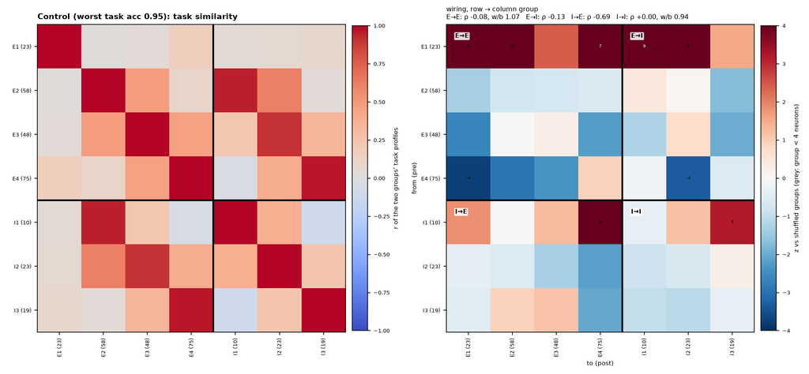

Left: task similarity $r$ between group profiles. Right: synapses row → column group, $z$ vs 500 shuffles of group labels (grey: group < 4 neurons). This network (seed 4): $\rho_{\text{I}\to\text{E}} = -0.69$, $\rho_{\text{E}\to\text{I}} = -0.13$, E→E within/between 1.07. All 5 seeds: $\rho_{\text{I}\to\text{E}}$ −0.69 to −0.31; $\rho_{\text{E}\to\text{I}}$ −0.13 to +0.05; E→E 1.05–1.15.

## Task similarity and synapses: rate constraint experimental

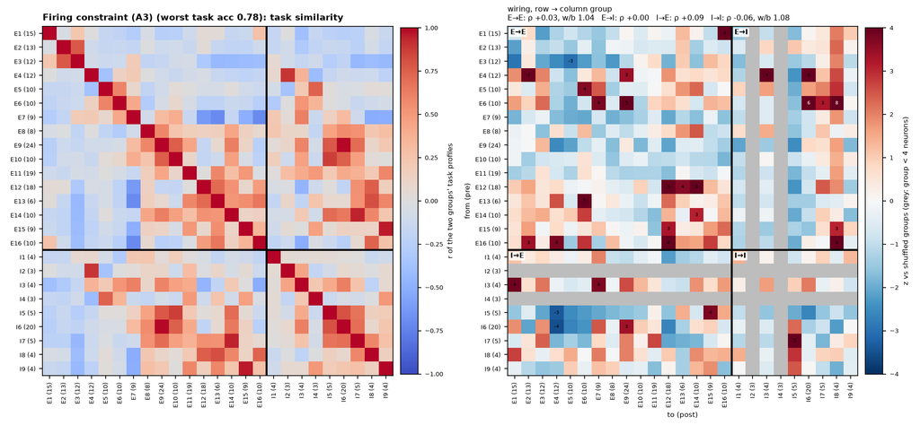

Left: task similarity $r$ between group profiles. Right: synapses row → column group, $z$ vs 500 shuffles of group labels (grey: group < 4 neurons). This network (seed 4): $\rho_{\text{I}\to\text{E}} = +0.09$, $\rho_{\text{E}\to\text{I}} = 0.00$, E→E within/between 1.04. All 5 seeds: $\rho_{\text{I}\to\text{E}}$ −0.05 to +0.09; $\rho_{\text{E}\to\text{I}}$ −0.15 to +0.14; E→E 1.02–1.09.

## Task similarity and synapses: synaptic constraint experimental

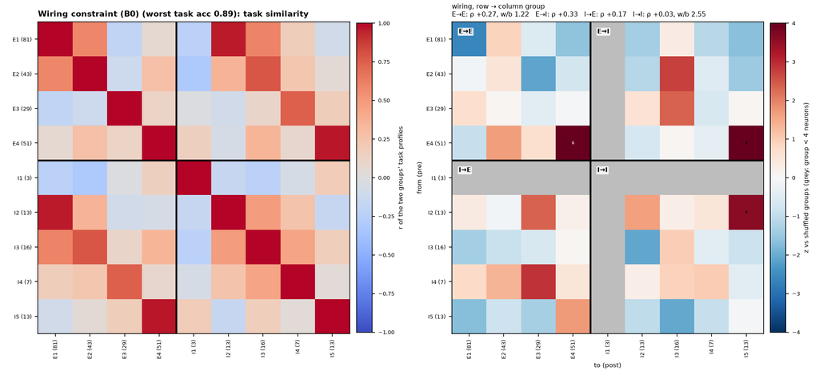

Left: task similarity $r$ between group profiles. Right: synapses row → column group, $z$ vs 500 shuffles of group labels (grey: group < 4 neurons). This network (seed 4): $\rho_{\text{I}\to\text{E}} = +0.17$, $\rho_{\text{E}\to\text{I}} = +0.33$, E→E within/between 1.22. All 5 seeds: $\rho_{\text{I}\to\text{E}}$ −0.05 to +0.45; $\rho_{\text{E}\to\text{I}}$ −0.03 to +0.40; E→E 1.15–5.89.

## Task similarity and synapses: both constraints experimental

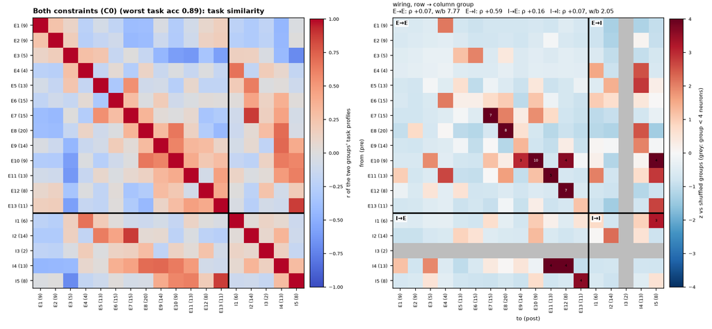

Left: task similarity $r$ between group profiles. Right: synapses row → column group, $z$ vs 500 shuffles of group labels (grey: group < 4 neurons). This network (seed 4): $\rho_{\text{I}\to\text{E}} = +0.16$, $\rho_{\text{E}\to\text{I}} = +0.59$, E→E within/between 7.77. All 5 seeds: $\rho_{\text{I}\to\text{E}}$ +0.07 to +0.39; $\rho_{\text{E}\to\text{I}}$ +0.36 to +0.62; E→E 2.84–7.77.

## Task variance per task period experimental

We split each task into its periods $p \in \{$stimulus 1, memory 1, stimulus 2, memory 2, response$\}$, leave out fixation, and get 59 (task, period) rows.

$$\mathrm{TV}_{i,(a,p)} = \frac{1}{|T_p|}\sum_{t \in T_p} \mathrm{Var}_{\text{trials}}\, r_i(t)$$

Length-weighted mean over a task’s periods = per-task TV (to $3\cdot10^{-7}$).

Normalise: each active neuron (total TV > 1% of max) divided by its max over the rows, $x_i \in [0,1]^{59}$.

Ward clustering of neurons (columns) and of task periods (rows): merge the pair that least increases the within-cluster variance,

$$\Delta(A,B) = \frac{|A|\,|B|}{|A|+|B|}\,\big\lVert \mu_A - \mu_B \big\rVert^2 .$$

$k$ per axis: highest silhouette over $k = 3,\dots,39$. Sparsity: fraction of entries < 0.15.

Differences from Driscoll et al.: active rule (>1% vs >10⁻³), random trials instead of a stimulus grid, $k$ by silhouette instead of a fixed cut height; E and I clustered together.

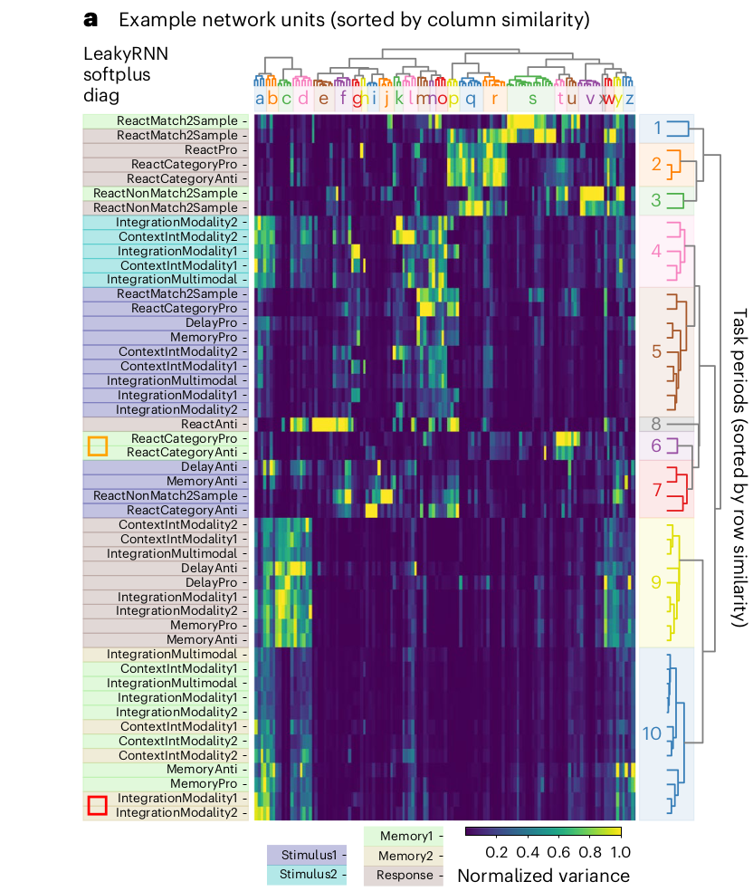

Driscoll, Shenoy & Sussillo (2024). *Nat. Neurosci.* 27, 1349–1363. Fig. 3a.

## Task periods: control vs. rate constraint experimental

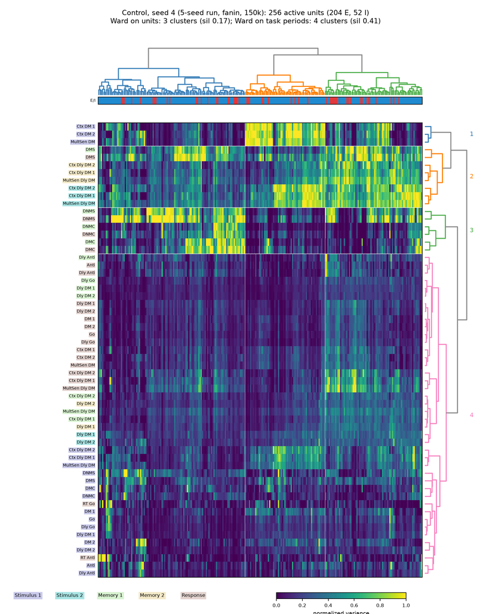

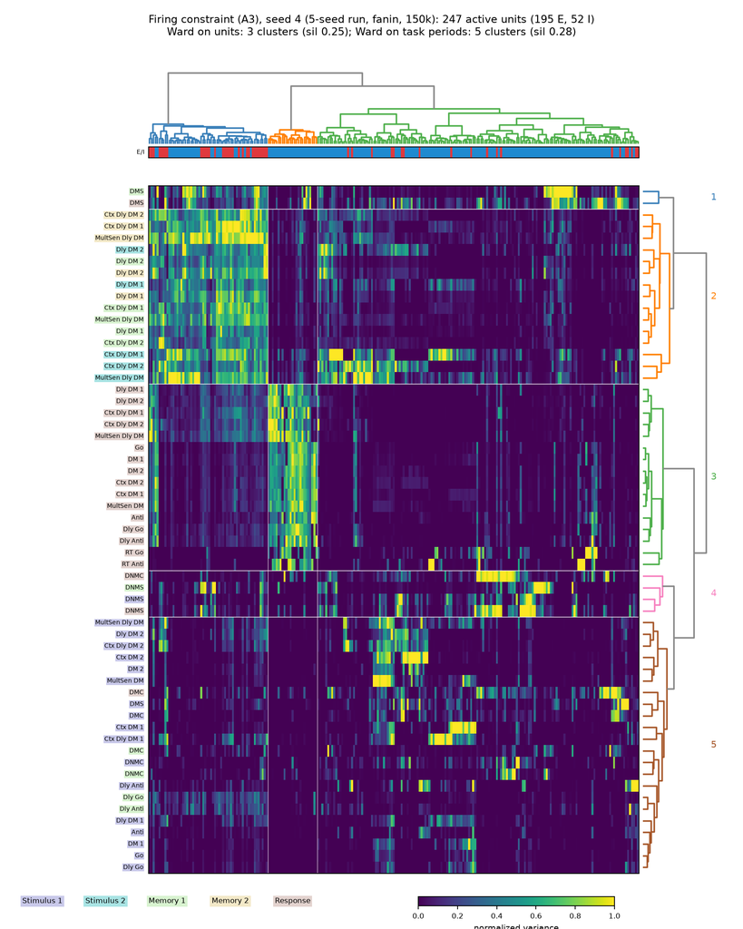

Example network (seed 4). Sparsity E / I: control 0.43 / 0.39, rate constraint 0.79 / 0.62. Row label colour = period type.

## Task periods: synaptic vs. both constraints experimental

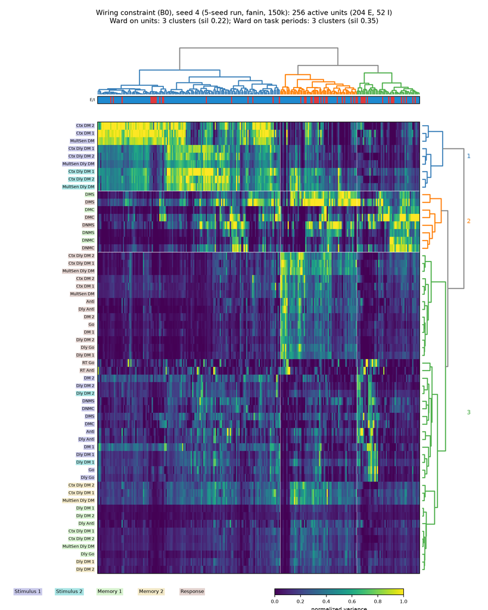

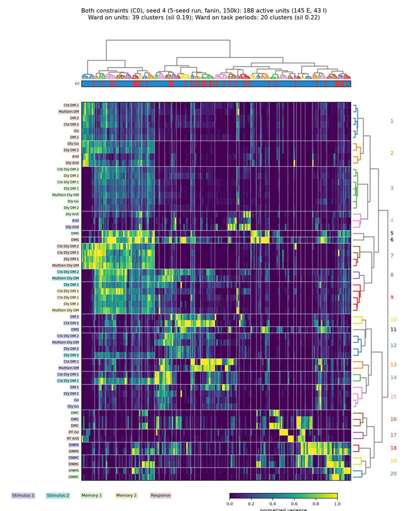

Example network (seed 4). Sparsity E / I: synaptic constraint 0.48 / 0.48, both constraints 0.69 / 0.63. Row label colour = period type.

## Lesions on task-period groups experimental

Groups: per-period task variance (59 rows, each neuron divided by its max), Ward clustering, E and I separately, fixed $k$: 14 E groups (5 task families × stimulus / memory / response; DM has no memory period), 5 I groups (the task families).

Lesion group $g$: $r_i(t) = 0$ for all $i \in g$ at every time step (Driscoll et al. 2024).

Damage on task $a$, relative to the intact network (10 eval seeds × 64 trials, no noise):

$$\Delta_{g,a} = \frac{\mathrm{acc}_{g,a} - \mathrm{acc}_a}{\mathrm{acc}_a}$$

Module contrast: does lesioning $g$ hurt a set of tasks $M$ more than a reference set?

$$C_{g,M} = \big\langle \Delta_{g,a} \big\rangle_{a \in M} - \big\langle \Delta_{g,a} \big\rangle_{a \in \mathrm{ref}(M)},
\qquad C < 0:\ M \text{ hurt more}$$

| Anti tasks | vs. all other tasks |
| --- | --- |
| tasks with a delay (Dly, Go, Anti) | vs. all other tasks |
| modality 1 DM tasks | vs. modality 2 |
| DMC (categorical memory) | vs. Dly tasks (continuous memory) |

As Driscoll et al. Fig. 5. No control for group size. v1 task battery, seed 4.

## Lesions on task-period groups: four points experimental

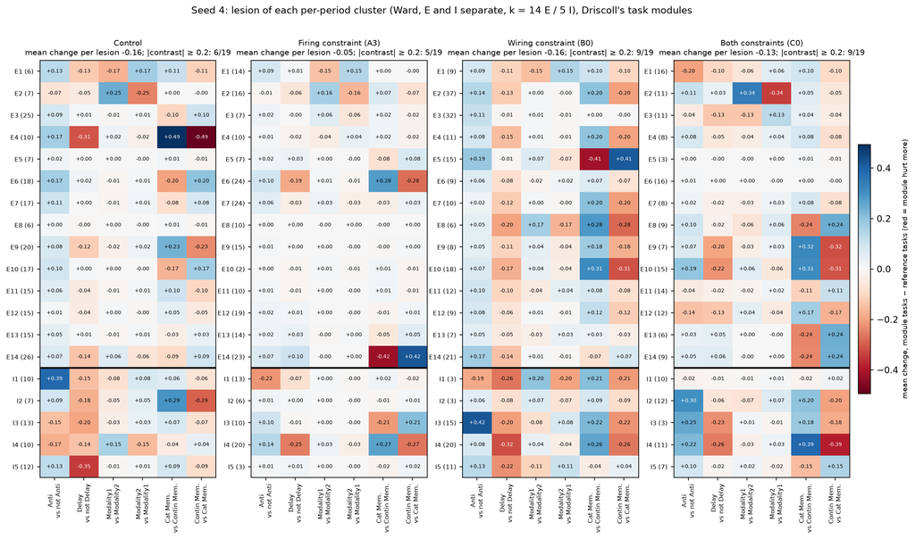

Mean change per lesion: control −0.16, rate constraint −0.05, synaptic constraint −0.16, both constraints −0.13. Groups with $|C| \geq 0.2$: 6, 5, 9 and 9 of 19. Results change with $k$.

## The front, interactive extra

[interactive chart not shown]

Same networks as “The front”: drag to rotate, hover for one network (run, budgets, accuracy, costs, synapses kept).

## Like-to-like AUC, mean over 5 seeds extra

|  | Control | Rate constraint | Synaptic constraint | Both constraints |
| --- | --- | --- | --- | --- |
| E → E | 0.53 | 0.52 | 0.57 | 0.63 |
| E → I | 0.53 | 0.51 | 0.62 | 0.66 |
| I → E | 0.46 | 0.47 | 0.58 | 0.61 |
| I → I | 0.46 | 0.48 | 0.60 | 0.62 |

Same numbers as “Like-to-like connectivity: all 20 networks” (per-task profiles, front run). Purple: like-to-like; orange: like-to-unlike. Hover a cell: seeds with $p < 0.05$.